# Codebook for nhanes_clean

Autogenerated data summary from dataReporter

2025-09-26 16:35:40.245019

# Data report overview

The dataset examined has the following dimensions:

| Feature | Result |
| --- | --- |
| Number of observations | 1590 |
| Number of variables | 14 |

# Codebook summary table

| Label | Variable | Class | # unique values | Missing | Description |
| --- | --- | --- | --- | --- | --- |
| Subject ID: Individual Identifier | **SEQN** | numeric | 1590 | 0.00 % |  |
| Age in years at screening (40-65) | **RIDAGEYR** | numeric | 26 | 0.00 % |  |
| Sex: male or female | **RIAGENDR** | factor | 2 | 0.00 % |  |
| Race / Ethnicity | **RIDRETH1** | factor | 5 | 0.00 % |  |
| Blood lead (µg/dL) | **LBXBPB** | numeric | 245 | 0.00 % |  |
| Blood cadmium (µg/dL) | **LBXBCD** | numeric | 110 | 0.00 % |  |
| Blood manganese (µg/dL) | **LBXBMN** | numeric | 845 | 0.00 % |  |
| Systolic BP, first reading | **BPXSY1** | numeric | 42 | 0.00 % |  |
| Diastolic BP, first reading | **BPXDI1** | numeric | 25 | 0.00 % |  |
| Blood lead after outlier removal and log transformation | **LBXBPB_clean_log** | numeric | 245 | 0.00 % |  |
| Blood cadmium after outlier removal and log transformation | **LBXBCD_clean_log** | numeric | 110 | 0.00 % |  |
| Blood manganese after outlier removal and log transformation | **LBXBMN_clean_log** | numeric | 845 | 0.00 % |  |
| Systolic BP, first reading after outlier removal | **BPXSY1_clean** | numeric | 42 | 0.00 % |  |
| Diastolic BP, first reading after outlier removal | **BPXDI1_clean** | numeric | 25 | 0.00 % |  |

# Variable list

## SEQN

*Subject ID: Individual Identifier*

| Feature | Result |
| --- | --- |
| Variable type | numeric |
| Number of missing obs. | 0 (0 %) |
| Number of unique values | 1590 |
| Median | 98328.5 |
| 1st and 3rd quartiles | 96018.25; 100753.5 |
| Min. and max. | 93711; 102954 |

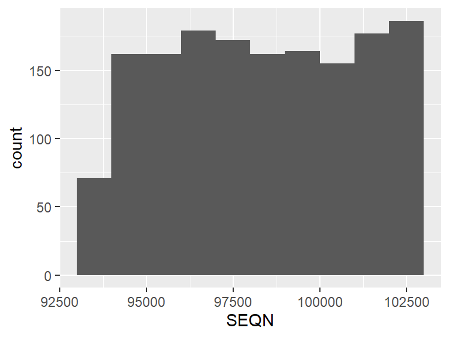

## RIDAGEYR

*Age in years at screening (40-65)*

| Feature | Result |
| --- | --- |
| Variable type | numeric |
| Number of missing obs. | 0 (0 %) |
| Number of unique values | 26 |
| Median | 55 |
| 1st and 3rd quartiles | 47; 60 |
| Min. and max. | 40; 65 |

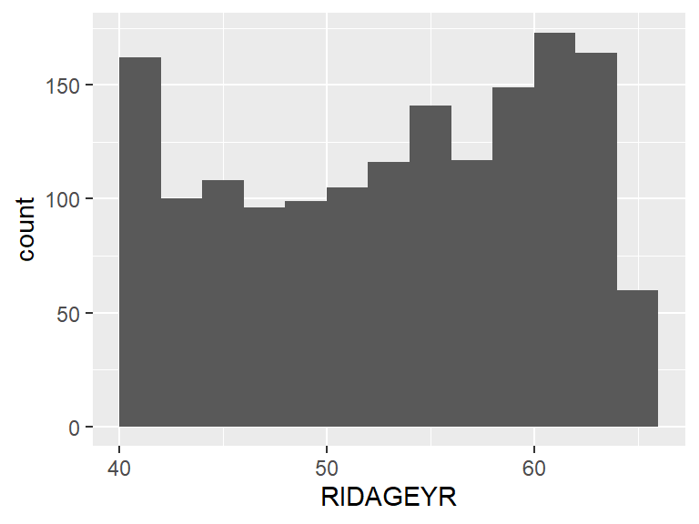

## RIAGENDR

*Sex: male or female*

| Feature | Result |
| --- | --- |
| Variable type | factor |
| Number of missing obs. | 0 (0 %) |
| Number of unique values | 2 |
| Mode | “Female” |
| Reference category | Male |

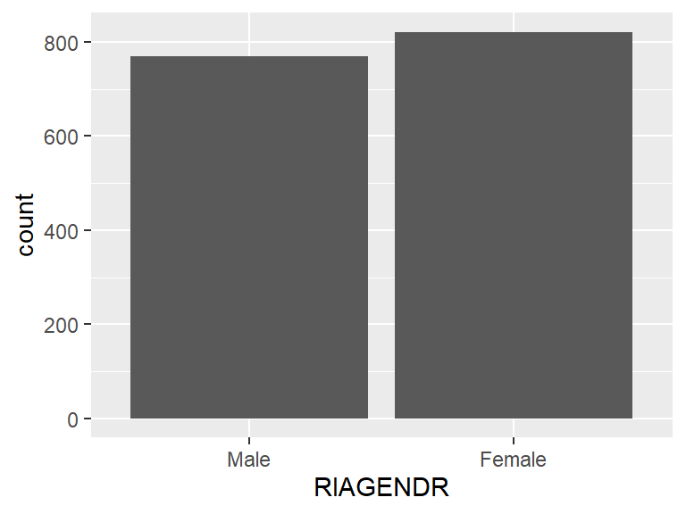

- Observed factor levels: "Female", "Male".

## RIDRETH1

*Race / Ethnicity*

| Feature | Result |
| --- | --- |
| Variable type | factor |
| Number of missing obs. | 0 (0 %) |
| Number of unique values | 5 |
| Mode | “Non-Hispanic White” |
| Reference category | Mexican American |

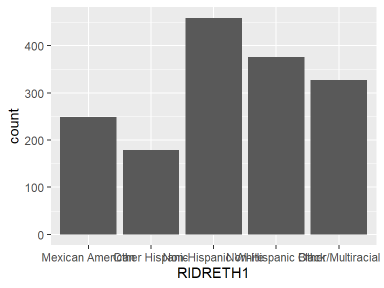

- Observed factor levels: "Mexican American", "Non-Hispanic Black", "Non-Hispanic White", "Other Hispanic", "Other/Multiracial".

## LBXBPB

*Blood lead (µg/dL)*

| Feature | Result |
| --- | --- |
| Variable type | numeric |
| Number of missing obs. | 0 (0 %) |
| Number of unique values | 245 |
| Median | 0.93 |
| 1st and 3rd quartiles | 0.61; 1.33 |
| Min. and max. | 0.12; 2.77 |

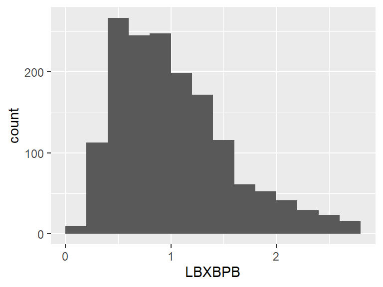

## LBXBCD

*Blood cadmium (µg/dL)*

| Feature | Result |
| --- | --- |
| Variable type | numeric |
| Number of missing obs. | 0 (0 %) |
| Number of unique values | 110 |
| Median | 0.3 |
| 1st and 3rd quartiles | 0.18; 0.48 |
| Min. and max. | 0.07; 1.21 |

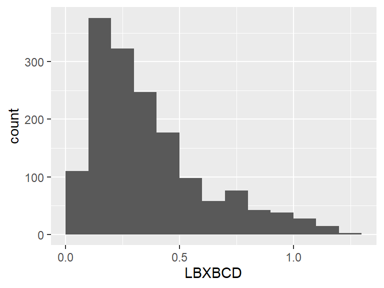

## LBXBMN

*Blood manganese (µg/dL)*

| Feature | Result |
| --- | --- |
| Variable type | numeric |
| Number of missing obs. | 0 (0 %) |
| Number of unique values | 845 |
| Median | 9.27 |
| 1st and 3rd quartiles | 7.49; 11.49 |
| Min. and max. | 3.07; 18.34 |

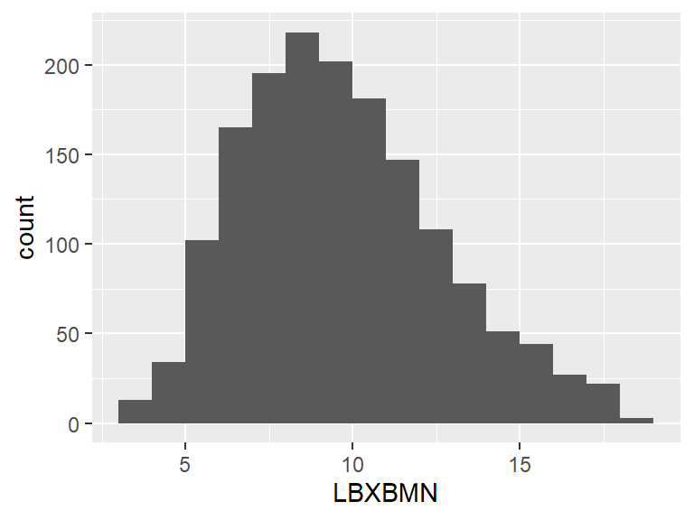

## BPXSY1

*Systolic BP, first reading*

| Feature | Result |
| --- | --- |
| Variable type | numeric |
| Number of missing obs. | 0 (0 %) |
| Number of unique values | 42 |
| Median | 126 |
| 1st and 3rd quartiles | 116; 136 |
| Min. and max. | 88; 170 |

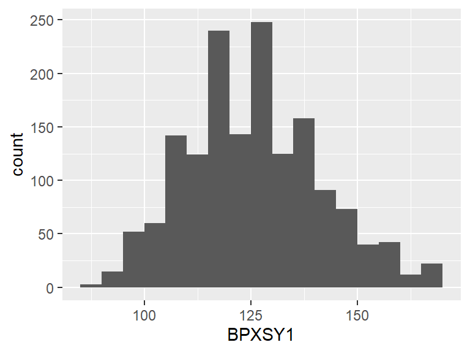

## BPXDI1

*Diastolic BP, first reading*

| Feature | Result |
| --- | --- |
| Variable type | numeric |
| Number of missing obs. | 0 (0 %) |
| Number of unique values | 25 |
| Median | 76 |
| 1st and 3rd quartiles | 70; 82 |
| Min. and max. | 52; 100 |

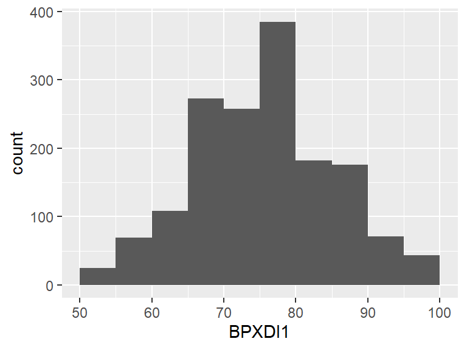

## LBXBPB_clean_log

*Blood lead after outlier removal and log transformation*

| Feature | Result |
| --- | --- |
| Variable type | numeric |
| Number of missing obs. | 0 (0 %) |
| Number of unique values | 245 |
| Median | 0.66 |
| 1st and 3rd quartiles | 0.48; 0.85 |
| Min. and max. | 0.11; 1.33 |

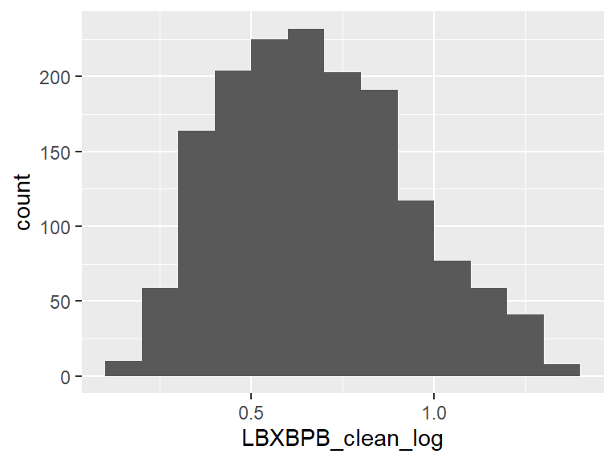

## LBXBCD_clean_log

*Blood cadmium after outlier removal and log transformation*

| Feature | Result |
| --- | --- |
| Variable type | numeric |
| Number of missing obs. | 0 (0 %) |
| Number of unique values | 110 |
| Median | 0.26 |
| 1st and 3rd quartiles | 0.17; 0.39 |
| Min. and max. | 0.07; 0.79 |

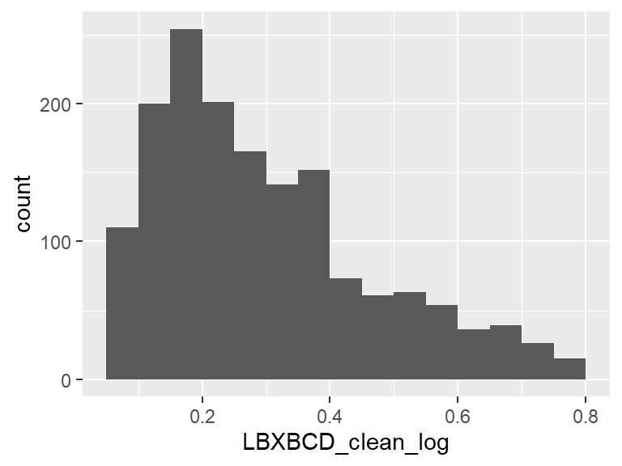

## LBXBMN_clean_log

*Blood manganese after outlier removal and log transformation*

| Feature | Result |
| --- | --- |
| Variable type | numeric |
| Number of missing obs. | 0 (0 %) |
| Number of unique values | 845 |
| Median | 2.33 |
| 1st and 3rd quartiles | 2.14; 2.52 |
| Min. and max. | 1.4; 2.96 |

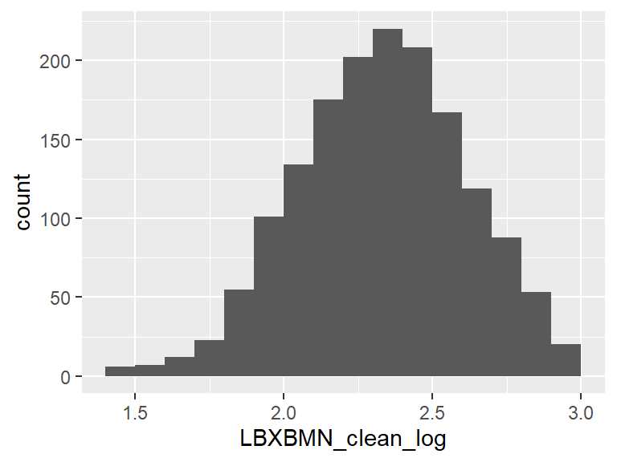

## BPXSY1_clean

*Systolic BP, first reading after outlier removal*

| Feature | Result |
| --- | --- |
| Variable type | numeric |
| Number of missing obs. | 0 (0 %) |
| Number of unique values | 42 |
| Median | 126 |
| 1st and 3rd quartiles | 116; 136 |
| Min. and max. | 88; 170 |

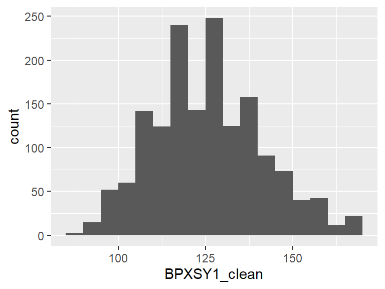

## BPXDI1_clean

*Diastolic BP, first reading after outlier removal*

| Feature | Result |
| --- | --- |
| Variable type | numeric |
| Number of missing obs. | 0 (0 %) |
| Number of unique values | 25 |
| Median | 76 |
| 1st and 3rd quartiles | 70; 82 |
| Min. and max. | 52; 100 |

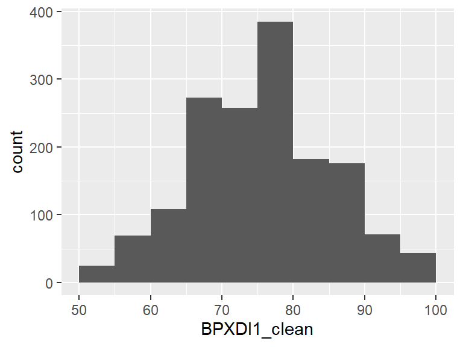

Report generation information:

- Created by: Could not determine from system (username: `User`).
- Report creation time: Fri Sep 26 2025 16:35:41
- Report was run from directory: `C:/Users/User/sofiyavyshnya`
- dataReporter v1.0.5 [Pkg: 2025-04-13 from standard (@1.0.5)]
- R version 4.5.1 (2025-06-13 ucrt).
- Platform: x86_64-w64-mingw32/x64(America/New_York).
- Function call: `dataReporter::makeDataReport(data = nhanes_clean, output = "html", mode = c("summarize", "visualize", "check"), smartNum = FALSE, file = "my_data_report.html", replace = TRUE, checks = list( character = "showAllFactorLevels", factor = "showAllFactorLevels", labelled = "showAllFactorLevels", haven_labelled = "showAllFactorLevels", numeric = NULL, integer = NULL, logical = NULL, Date = NULL), listChecks = FALSE, maxProbVals = Inf, codebook = TRUE, reportTitle = "Codebook for nhanes_clean")`